# TP2

# Preliminary analysis of the data

## Question 1

```r
> prostate.data <- read.table("prostate.data.txt" , header = TRUE)
> prostate.data <- prostate.data[, -10] # pour supprimer le colonne train
> View(prostate.data)
>
> str(prostate.data)
```

```
'data.frame':   97 obs. of  9 variables:
 $ lcavol : num  -0.58 -0.994 -0.511 -1.204 0.751 ...
 $ lweight: num  2.77 3.32 2.69 3.28 3.43 ...
 $ age    : int  50 58 74 58 62 50 64 58 47 63 ...
 $ lbph   : num  -1.39 -1.39 -1.39 -1.39 -1.39 ...
 $ svi    : int  0 0 0 0 0 0 0 0 0 0 ...
 $ lcp    : num  -1.39 -1.39 -1.39 -1.39 -1.39 ...
 $ gleason: int  6 6 7 6 6 6 6 6 6 6 ...
 $ pgg45  : int  0 0 20 0 0 0 0 0 0 0 ...
 $ lpsa   : num  -0.431 -0.163 -0.163 -0.163 0.372 ...
```

```r
> summary(prostate.data)
```

```
     lcavol           lweight           age             lbph
 Min.   :-1.3471   Min.   :2.375   Min.   :41.00   Min.   :-1.3863
 1st Qu.: 0.5128   1st Qu.:3.376   1st Qu.:60.00   1st Qu.:-1.3863
 Median : 1.4469   Median :3.623   Median :65.00   Median : 0.3001
 Mean   : 1.3500   Mean   :3.629   Mean   :63.87   Mean   : 0.1004
 3rd Qu.: 2.1270   3rd Qu.:3.876   3rd Qu.:68.00   3rd Qu.: 1.5581
 Max.   : 3.8210   Max.   :4.780   Max.   :79.00   Max.   : 2.3263
      svi              lcp             gleason          pgg45
 Min.   :0.0000   Min.   :-1.3863   Min.   :6.000   Min.   :  0.00
 1st Qu.:0.0000   1st Qu.:-1.3863   1st Qu.:6.000   1st Qu.:  0.00
 Median :0.0000   Median :-0.7985   Median :7.000   Median : 15.00
 Mean   :0.2165   Mean   :-0.1794   Mean   :6.753   Mean   : 24.38
 3rd Qu.:0.0000   3rd Qu.: 1.1787   3rd Qu.:7.000   3rd Qu.: 40.00
 Max.   :1.0000   Max.   : 2.9042   Max.   :9.000   Max.   :100.00
      lpsa
 Min.   :-0.4308
 1st Qu.: 1.7317
 Median : 2.5915
 Mean   : 2.4784
 3rd Qu.: 3.0564
 Max.   : 5.5829
```

## Question 2

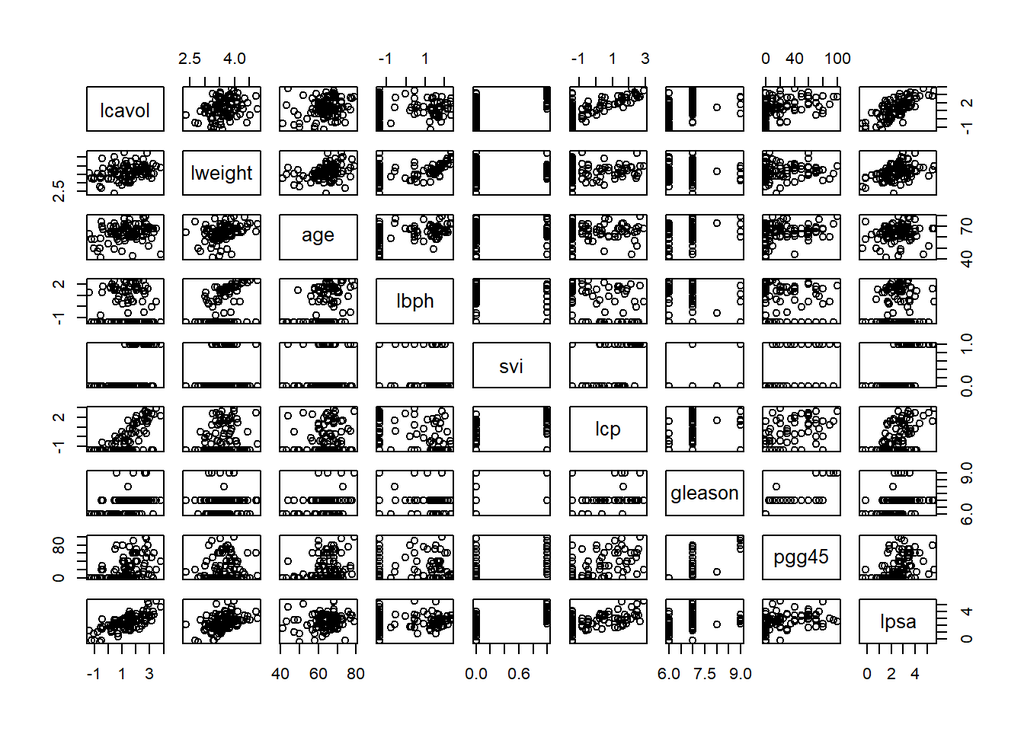

```r
> pairs(prostate.data)
```

```r
> # ou on peut calculer la matrice de corrolation :
> cor(prostate.data)
```

```
           lcavol    lweight       age         lbph         svi          lcp
lcavol  1.0000000 0.28052138 0.2249999  0.027349703  0.53884500  0.675310484
lweight 0.2805214 1.00000000 0.3479691  0.442264399  0.15538490  0.164537142
age     0.2249999 0.34796911 1.0000000  0.350185896  0.11765804  0.127667752
lbph    0.0273497 0.44226440 0.3501859  1.000000000 -0.08584324 -0.006999431
svi     0.5388450 0.15538490 0.1176580 -0.085843238  1.00000000  0.673111185
lcp     0.6753105 0.16453714 0.1276678 -0.006999431  0.67311118  1.000000000
gleason 0.4324171 0.05688209 0.2688916  0.077820447  0.32041222  0.514830063
pgg45   0.4336522 0.10735379 0.2761124  0.078460018  0.45764762  0.631528246
lpsa    0.7344603 0.43331938 0.1695928  0.179809404  0.56621822  0.548813175
           gleason      pgg45      lpsa
lcavol  0.43241706 0.43365225 0.7344603
lweight 0.05688209 0.10735379 0.4333194
age     0.26889160 0.27611245 0.1695928
lbph    0.07782045 0.07846002 0.1798094
svi     0.32041222 0.45764762 0.5662182
lcp     0.51483006 0.63152825 0.5488132
gleason 1.00000000 0.75190451 0.3689868
pgg45   0.75190451 1.00000000 0.4223159
lpsa    0.36898681 0.42231586 1.0000000
```

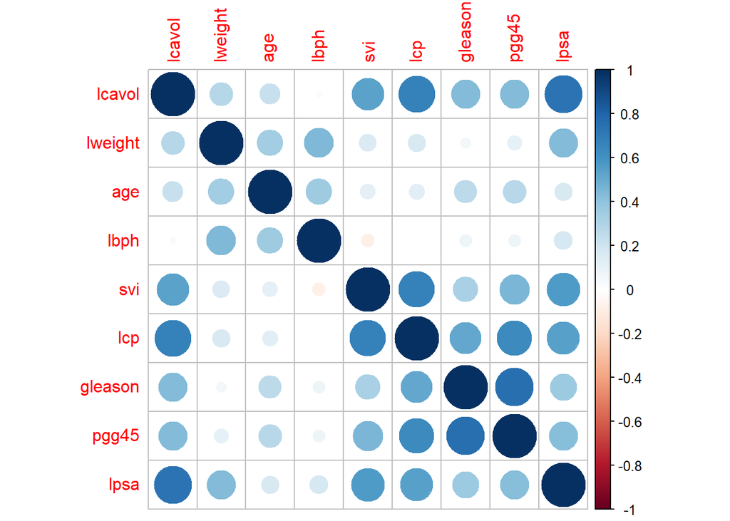

```r
> library(corrplot)
> corrplot(cor(prostate.data))
```

D’après la matrice de corrélation et sa représentation, on n’a que le variable le plus relier à lcavol sont lpsa et lcp .

# Linear regression

## Question 3

- RQ : Cas de régression si l’un de variables explicatives est catégorielle ?

```r
> # gleason and svi have to be considered as qualitative variables: convert them with
> # factor().
>
> prostate.data$svi <- as.factor(prostate.data$svi)
> prostate.data$gleason <- as.factor(prostate.data$gleason)
> # verification :
> str(prostate.data)
```

```
'data.frame':   97 obs. of  9 variables:
 $ lcavol : num  -0.58 -0.994 -0.511 -1.204 0.751 ...
 $ lweight: num  2.77 3.32 2.69 3.28 3.43 ...
 $ age    : int  50 58 74 58 62 50 64 58 47 63 ...
 $ lbph   : num  -1.39 -1.39 -1.39 -1.39 -1.39 ...
 $ svi    : Factor w/ 2 levels "0","1": 1 1 1 1 1 1 1 1 1 1 ...
 $ lcp    : num  -1.39 -1.39 -1.39 -1.39 -1.39 ...
 $ gleason: Factor w/ 4 levels "6","7","8","9": 1 1 2 1 1 1 1 1 1 1 ...
 $ pgg45  : int  0 0 20 0 0 0 0 0 0 0 ...
 $ lpsa   : num  -0.431 -0.163 -0.163 -0.163 0.372 ...
```

```r
> # Régression lineaire : lcavol ~ .
> lm.all <- lm(lcavol ~ . , data = prostate.data)
> summary(lm.all)
```

```
Call:
lm(formula = lcavol ~ ., data = prostate.data)

Residuals:
     Min       1Q   Median       3Q      Max
-1.91436 -0.48444 -0.02664  0.54915  1.80062

Coefficients:
             Estimate Std. Error t value Pr(>|t|)
(Intercept) -1.406654   0.874455  -1.609   0.1114
lweight     -0.011246   0.211453  -0.053   0.9577
age          0.024782   0.011241   2.205   0.0301 *
lbph        -0.104200   0.058209  -1.790   0.0770 .
svi1        -0.220419   0.256351  -0.860   0.3923
lcp          0.402760   0.085074   4.734 8.58e-06 ***
gleason7     0.311676   0.215268   1.448   0.1513
gleason8    -0.710588   0.758827  -0.936   0.3517
gleason9     0.790135   0.487510   1.621   0.1087
pgg45       -0.009444   0.004540  -2.080   0.0405 *
lpsa         0.549573   0.090093   6.100 2.94e-08 ***
---
Signif. codes:  0 '***' 0.001 '**' 0.01 '*' 0.05 '.' 0.1 ' ' 1

Residual standard error: 0.6973 on 86 degrees of freedom
Multiple R-squared:  0.6865,    Adjusted R-squared:   0.65
F-statistic: 18.83 on 10 and 86 DF,  p-value: < 2.2e-16
```

## Question 4

```r
> confint(lm.all , level = 0.95)
```

```
                   2.5 %        97.5 %
(Intercept) -3.145013212  0.3317051396
lweight     -0.431599858  0.4091074596
age          0.002435876  0.0471289533
lbph        -0.219914296  0.0115152113
svi1        -0.730029034  0.2891903039
lcp          0.233638987  0.5718802443
gleason7    -0.116263131  0.7396155044
gleason8    -2.219087210  0.7979107787
gleason9    -0.179003633  1.7592727371
pgg45       -0.018468522 -0.0004191483
lpsa         0.370473639  0.7286725619
```

## Question 5

# What can you say about the effect of the lpsa variable :

- D’aprés le Resultat de la Régression linéaire on que le p-value du test de nullité du oefficnet du lpas est trés faible donc le choix du lpsa dans le modéle de régression est trés pertiante
- de meme avec un niveau de cofiance 95% on a que 0 n’appartient pas à l’intervalle de cofiance de lpsa ce qui confirme bien la pertiance de choix du lpas dans le modéle de régression

## Question 6

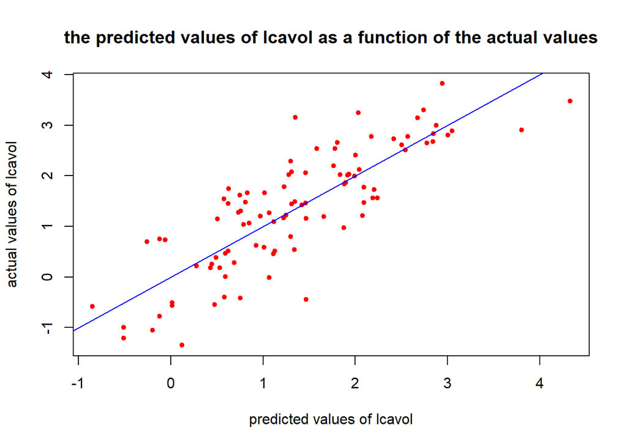

```r
> # Plot the predicted values of lcavol as a function of the actual values :
> plot(fitted.values(lm.all) , prostate.data$lcavol , col="red" , pch=20 ,
+      main="the predicted values of lcavol as a function of the actual values" ,
+      xlab="predicted values of lcavol" , ylab = "actual values of lcavol")
>
> abline(a=0 , b=1 , col="blue")
```

On observe bien que les points sont autoures de la droite y = x

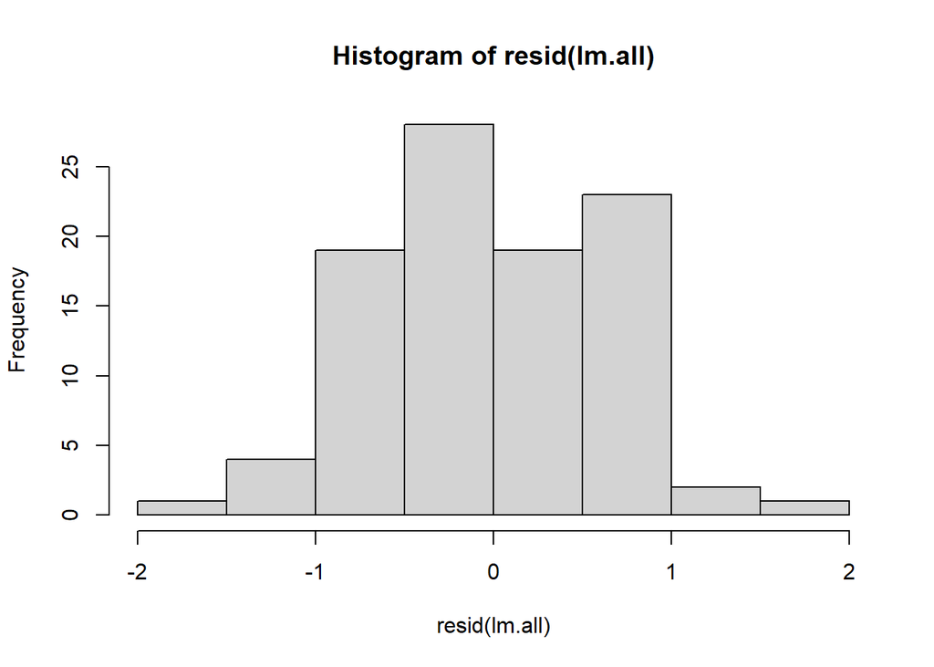

```r
> # Plot the histogram of residuals.
> # Can we admit that the residuals are normally distributed
> hist(resid(lm.all))
```

```r
> # Test de Shapiro
> shapiro.test(resid(lm.all)) # p-value = 70% => distrubtion normale
```

```
    Shapiro-Wilk normality test

data:  resid(lm.all)
W = 0.99026, p-value = 0.705
```

On a que le p-value est de 70% donc on bien adaptée la normalitée de residus .

```r
> #  Compute the residual sum of squares : RSS
> RSS <- sum((prostate.data$lcavol -  fitted.values(lm.all))^2)
> RSS
```

```
[1] 41.81407
```

```r
> # ou avec :
> sum(resid(lm.all)^2)
```

```
[1] 41.81407
```

## Question 7

# What do you think of the optimality of this model? :

## Question 8

```r
> # What happens if predictors lpsa and lcp are removed from the model? Try to explain this new # result
>
> summary(lm(lcavol ~ . - lpsa - lcp , data = prostate.data))
```

```
Call:
lm(formula = lcavol ~ . - lpsa - lcp, data = prostate.data)

Residuals:
     Min       1Q   Median       3Q      Max
-1.84488 -0.48256 -0.01752  0.58918  2.21990

Coefficients:
              Estimate Std. Error t value Pr(>|t|)
(Intercept) -1.9717103  1.1590310  -1.701 0.092442 .
lweight      0.5849583  0.2591548   2.257 0.026472 *
age          0.0072858  0.0146727   0.497 0.620739
lbph        -0.0746433  0.0771750  -0.967 0.336097
svi1         1.0245817  0.2714729   3.774 0.000291 ***
gleason7     0.8007406  0.2744312   2.918 0.004473 **
gleason8     0.6868720  0.9601171   0.715 0.476253
gleason9     1.1726480  0.6444380   1.820 0.072214 .
pgg45       -0.0004312  0.0056372  -0.076 0.939203
---
Signif. codes:  0 '***' 0.001 '**' 0.01 '*' 0.05 '.' 0.1 ' ' 1

Residual standard error: 0.9272 on 88 degrees of freedom
Multiple R-squared:  0.4327,    Adjusted R-squared:  0.3811
F-statistic:  8.39 on 8 and 88 DF,  p-value: 2.11e-08
```

$R^2 = 43%$ trés faibe par rapport au le modéle de régression précedent

## Question 9

```r
> # What happens if predictor lweight is removed from the model? Try to explain this new result
>
> summary(lm(lcavol ~ . - lweight , data = prostate.data))
```

```
Call:
lm(formula = lcavol ~ . - lweight, data = prostate.data)

Residuals:
     Min       1Q   Median       3Q      Max
-1.92186 -0.48695 -0.02231  0.55033  1.79957

Coefficients:
             Estimate Std. Error t value Pr(>|t|)
(Intercept) -1.434884   0.690938  -2.077   0.0408 *
age          0.024636   0.010835   2.274   0.0254 *
lbph        -0.105215   0.054671  -1.925   0.0576 .
svi1        -0.220032   0.254775  -0.864   0.3902
lcp          0.402601   0.084533   4.763 7.57e-06 ***
gleason7     0.313300   0.211868   1.479   0.1428
gleason8    -0.709297   0.754080  -0.941   0.3495
gleason9     0.793144   0.481431   1.647   0.1031
pgg45       -0.009438   0.004512  -2.092   0.0394 *
lpsa         0.547767   0.082965   6.602 3.07e-09 ***
---
Signif. codes:  0 '***' 0.001 '**' 0.01 '*' 0.05 '.' 0.1 ' ' 1

Residual standard error: 0.6933 on 87 degrees of freedom
Multiple R-squared:  0.6864,    Adjusted R-squared:  0.654
F-statistic: 21.16 on 9 and 87 DF,  p-value: < 2.2e-16
```

On a presque le méme $R^2$ du 1 ére modéle de Régression

# Anova – effects of the qualitative variables

## Question 10

```r
> lm.gleason <- lm(lcavol ~ gleason , data = prostate.data)
> summary(lm.gleason)
```

```
Call:
lm(formula = lcavol ~ gleason, data = prostate.data)

Residuals:
    Min      1Q  Median      3Q     Max
-2.2807 -0.5760 -0.1012  0.7630  2.6816

Coefficients:
            Estimate Std. Error t value Pr(>|t|)
(Intercept)   0.5649     0.1743   3.241  0.00165 **
gleason7      1.2050     0.2222   5.423 4.61e-07 ***
gleason8      0.8582     1.0458   0.821  0.41396
gleason9      1.5632     0.4930   3.171  0.00206 **
---
Signif. codes:  0 '***' 0.001 '**' 0.01 '*' 0.05 '.' 0.1 ' ' 1

Residual standard error: 1.031 on 93 degrees of freedom
Multiple R-squared:  0.2585,    Adjusted R-squared:  0.2346
F-statistic: 10.81 on 3 and 93 DF,  p-value: 3.696e-06
```

```r
> model.matrix(lm.gleason)
```

```
   (Intercept) gleason7 gleason8 gleason9
1            1        0        0        0
2            1        0        0        0
3            1        1        0        0
4            1        0        0        0
5            1        0        0        0
6            1        0        0        0
7            1        0        0        0
8            1        0        0        0
9            1        0        0        0
10           1        0        0        0
11           1        0        0        0
12           1        0        0        0
13           1        1        0        0
14           1        1        0        0
```

[output cut: 88 more lines]

## Question 11

```r
> formule.reg <- formula(lcavol ~ gleason - 1)
> lm.gleason <- lm(formule.reg , data = prostate.data)
> summary(lm.gleason)
```

```
Call:
lm(formula = formule.reg, data = prostate.data)

Residuals:
    Min      1Q  Median      3Q     Max
-2.2807 -0.5760 -0.1012  0.7630  2.6816

Coefficients:
         Estimate Std. Error t value Pr(>|t|)
gleason6   0.5649     0.1743   3.241  0.00165 **
gleason7   1.7699     0.1378  12.845  < 2e-16 ***
gleason8   1.4231     1.0311   1.380  0.17085
gleason9   2.1281     0.4611   4.615 1.26e-05 ***
---
Signif. codes:  0 '***' 0.001 '**' 0.01 '*' 0.05 '.' 0.1 ' ' 1

Residual standard error: 1.031 on 93 degrees of freedom
Multiple R-squared:  0.6812,    Adjusted R-squared:  0.6675
F-statistic: 49.67 on 4 and 93 DF,  p-value: < 2.2e-16
```

## Question 12

```r
> # anova :
> anova.lm <- anova(lm.gleason)
```

- On a que le p-value du Test d’anova est trés faible donc le volume du tumeur de prostate présente une variabilité importante selon le niveau de gleason .

```r
> # aov :
> av <- aov(lcavol ~ gleason - 1, data = prostate.data )
> summary(av)
```

```
          Df Sum Sq Mean Sq F value Pr(>F)
gleason    4 211.26   52.82   49.67 <2e-16 ***
Residuals 93  98.88    1.06
---
Signif. codes:  0 '***' 0.001 '**' 0.01 '*' 0.05 '.' 0.1 ' ' 1
```

```r
> # table of ANOVA one-way :
> # mean(prostate.data$lcavol[prostate.data$gleason == 6])
> # summary(prostate.data$gleason)
> model.tables(av)
```

```
Tables of effects

 gleason
          6     7     8     9
     0.5649  1.77 1.423 2.128
rep 35.0000 56.00 1.000 5.000
```

### Interprétation :

- On remarque dans le résultat de `model.tables(av)` que pour le niveau 9 de `gleason` avec seulement 5 observations, la moyenne est de 2.128, ce qui est supérieur aux autres niveaux. Ainsi, le volume de la tumeur de la prostate est assez important au niveau 9. Par contre, pour le niveau 6 avec 35 observations, la moyenne est de 0.5649, ce qui indique que le volume de la prostate au niveau 6 est très faible par rapport aux autres niveaux. Ceci est bien conforme avec les résultats de l’ANOVA présentés.

## Question 13

```r
> # two way ANOVA
> anova.svi.gleason.1 <- aov(lcavol ~ 0 + svi*gleason , data = prostate.data)
> summary(anova.svi.gleason.1)
```

```
            Df Sum Sq Mean Sq F value  Pr(>F)
svi          2 215.51  107.75 122.695 < 2e-16 ***
gleason      3  13.69    4.56   5.198 0.00233 **
svi:gleason  1   1.03    1.03   1.168 0.28270
Residuals   91  79.92    0.88
---
Signif. codes:  0 '***' 0.001 '**' 0.01 '*' 0.05 '.' 0.1 ' ' 1
```

```r
> coef(anova.svi.gleason.1)
```

```
         svi0          svi1      gleason7      gleason8      gleason9
    0.5649365     0.8237180     0.7888478     0.8581719     1.4596890
svi1:gleason7
    0.9676624
```

```r
> dummy.coef(anova.svi.gleason.1)
```

```
Full coefficients are

svi:                    0         1
                0.5649365 0.8237180
gleason:                6         7         8         9
                0.0000000 0.7888478 0.8581719 1.4596890
svi:gleason:          0:6       1:6       0:7       1:7       0:8       1:8
                0.0000000 0.0000000 0.0000000 0.9676624 0.0000000 0.0000000

svi:

gleason:

svi:gleason:          0:9       1:9
                0.0000000 0.0000000
```

## Question 14 : ??

```r
> # Consider now cross-effect only with 0+svi:gleason
> anova.svi.gleason.2 <- aov(lcavol ~ 0+svi:gleason , data = prostate.data)
> summary(anova.svi.gleason.2)
```

```
            Df Sum Sq Mean Sq F value Pr(>F)
svi:gleason  6 230.23   38.37   43.69 <2e-16 ***
Residuals   91  79.92    0.88
---
Signif. codes:  0 '***' 0.001 '**' 0.01 '*' 0.05 '.' 0.1 ' ' 1
```

# Best subset selection

## Question 15 :

```r
> # ?deviance
>
> lm.pro.5a <- lm(lcavol ~ 1, data= prostate.data) # taille = 0
> lm.pro.5b <- lm(lcavol ~ ., data=prostate.data[, c(1,2,3)]) # taille = 3
> lm.pro.5c <- lm(lcavol ~ ., data=prostate.data[, c(1,2,5)]) # taille = 3
>
> # la fonction deviance sur un objet lm calcul le RSS
> #  RSS = sum(resid(lm.pro.5a)^2)
> deviance(lm.pro.5a)
```

```
[1] 133.359
```

```r
> deviance(lm.pro.5b)
```

```
[1] 120.4025
```

```r
> deviance(lm.pro.5c)
```

```
[1] 89.34527
```

```r
> # ?anova
> # Tableau de devaince entre les modeles :
> anova(lm.pro.5a, lm.pro.5b, lm.pro.5c)
```

```
Analysis of Variance Table

Model 1: lcavol ~ 1
Model 2: lcavol ~ lweight + age
Model 3: lcavol ~ lweight + svi
  Res.Df     RSS Df Sum of Sq      F Pr(>F)
1     96 133.359
2     94 120.403  2    12.957 5.0577 0.0082 **
3     94  89.345  0    31.057
---
Signif. codes:  0 '***' 0.001 '**' 0.01 '*' 0.05 '.' 0.1 ' ' 1
```

## Question 16

```r
> # Compute the residual sums of squares for all models of size k = 2 using the code below :
>
> all2colnum <- rbind(1, 1+combn(8, 2))
>
> #compute
> all2colrss <- sapply(1:NCOL(all2colnum), function(i) deviance(lm(lcavol ~ ., data=prostate.data[, all2colnum[,i]])))
>
>
> #add names
> names(all2colrss) <- sapply(1:NCOL(all2colnum), function(i) paste(colnames(prostate.data)[all2colnum[-1,i]], collapse = "-"))
>
> all2colrss
```

```
    lweight-age    lweight-lbph     lweight-svi     lweight-lcp lweight-gleason
      120.40250       121.31398        89.34527        68.60765        92.16219
  lweight-pgg45    lweight-lpsa        age-lbph         age-svi         age-lcp
      100.89503        61.18712       126.20551        91.10619        69.93021
    age-gleason       age-pgg45        age-lpsa        lbph-svi        lbph-lcp
       97.84635       106.68069        60.03570        93.90983        72.40419
   lbph-gleason      lbph-pgg45       lbph-lpsa         svi-lcp     svi-gleason
       98.71896       108.27432        59.90979        70.80917        80.94378
      svi-pgg45        svi-lpsa     lcp-gleason       lcp-pgg45        lcp-lpsa
       88.73558        58.45219        67.81615        72.52999        47.27810
  gleason-pgg45    gleason-lpsa      pgg45-lpsa
       96.98748        56.94574        58.94625
```

```r
> all2colrss[all2colrss == min(all2colrss)]
```

```
lcp-lpsa
 47.2781
```

Donc le Resultat est lcp-lpsa avc RSS = 47.2781 , donc pour un modéle de taille 2 le meilleur choix qui minimise RSS c’est le choix de lcp-lpsa .

## Question 17

```r
> # For each value of k ∈ {0, . . . , 8}, select the set of predictors that minimizes the residual sum of squares:
> # make a function
>
> RSS.min.K <- function(k) {
+   allKCombn <- rbind(1 , 1+combn(8 ,k))
+   all.RSS <- sapply(1:NCOL(allKCombn), function(i) deviance(lm(lcavol ~ . , data = prostate.data[ , allKCombn[, i]])))
+   names(all.RSS) <- sapply(1:NCOL(allKCombn) , function(i) paste(colnames(prostate.data)[allKCombn[-1, i]], collapse = "-" ))
+   return(all.RSS[all.RSS == min(all.RSS)])
+ }
>
> RSS.min.v <- sapply(1:8 , FUN = RSS.min.K)
> RSS.min.v
```

```
                                       lpsa
                                   61.42091
                                   lcp-lpsa
                                   47.27810
                               age-lcp-lpsa
                                   46.23783
                          age-lbph-lcp-lpsa
                                   44.87841
                 age-lcp-gleason-pgg45-lpsa
                                   43.68997
            age-lbph-lcp-gleason-pgg45-lpsa
                                   42.17393
        age-lbph-svi-lcp-gleason-pgg45-lpsa
                                   41.81544
lweight-age-lbph-svi-lcp-gleason-pgg45-lpsa
                                   41.81407
```

```r
> names(RSS.min.v)[2]
```

```
[1] "lcp-lpsa"
```

```r
> strsplit(names(RSS.min.v)[2] ,"-")[[1]]
```

```
[1] "lcp"  "lpsa"
```

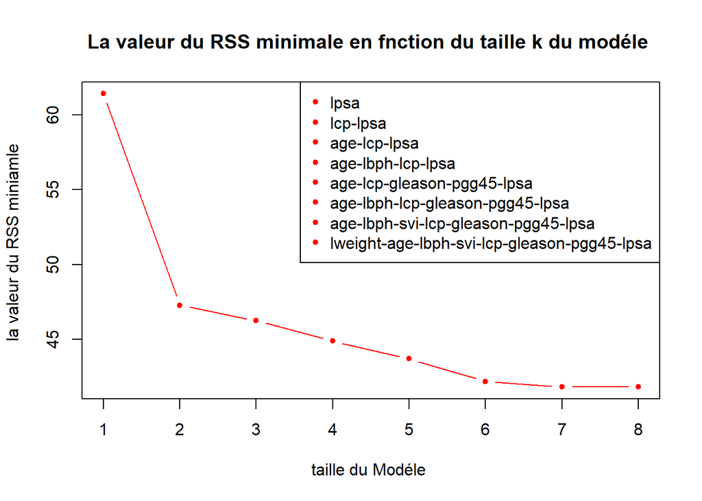

```r
> plot(1:8 , RSS.min.v , col="red" , pch = 20 ,
+      main="La valeur du RSS minimale en fnction du taille k du modéle " ,
+      xlab ="taille du Modéle " , ylab = "la valeur du RSS miniamle " ,
+      type = "b")
> legend("topright" , legend = names(RSS.min.v) , col = "red" , pch=20 )
```

## Question 18

# Do you think that minimizing the residual sum of squares is well suited to select the optimal size for

# the regression models? Could you suggest another possibility? :

On peut utiliser le coefficent de détermination $R^2$ au lieu RSS

# Split-validation

## Question 19

La validation croisée “split-validation”, est une technique utilisée pour évaluer la performance d’un modèle prédictif.

L’idée principale de la validation croisée est de diviser l’ensemble de données en plusieurs sous-ensembles (ou “folds”), d’utiliser un sous-ensemble pour tester le modèle et les autres pour l’entraînement, puis de répéter ce processus plusieurs fois en changeant le sous-ensemble de test à chaque fois. Les performances du modèle sont ensuite moyennées sur les différentes itérations pour obtenir une estimation plus fiable de sa capacité prédictive.

## Question 20

```r
> test <- 1:NROW(prostate.data) %% 3 == 0
>
> # Let us assume that the best model is of size 2
> RSS.min.v[2] # (lcp , lpsa) -> (6 , 9)
```

```
lcp-lpsa
 47.2781
```

```r
> # ?subset to see the subset argument
> # Modéle de regression lcavol ~ lcp + lpsa sur le 2/3 de data :
> lm.lcp.lpsa <- lm(lcavol ~ . , data = prostate.data[ , c(1 , 6 ,9)] , subset = !test)
```

```r
> # What is the mean training error for the model :
> lcavol.subset <- subset(prostate.data , subset = !test)$lcavol
> trainig_err.mean <- mean((lcavol.subset - fitted.values(lm.lcp.lpsa))^2)
> trainig_err.mean
```

```
[1] 0.4616663
```

Donc en moyenne l’erreur d’entrainment du Modéle est de 0.4616

## Question 21

```r
> # Predict values of lcavol on the validation set for the regression model of size two :
> data.test <- subset(prostate.data[ , c(1, 6 , 9)] , subset = test)
>
> predict.vec.test <- predict(lm.lcp.lpsa , newdata =  data.test)
>
> predict.err.mean <- mean((data.test$lcavol - predict.vec.test)^2)
> predict.err.mean
```

```
[1] 0.5672302
```

Donc en moyenne l’erreur de validation du Modéle est de 0.5672

## Question 22

```r
> index <- function(k) {
+   vec <- c("lcavol" ,strsplit(names(RSS.min.v)[k] ,"-")[[1]])
+   return(vec)
+ }
>
>
> err.training.val <- function(k) {
+
+   # on divise df en deux partie :
+   df.training <- subset(prostate.data[ , index(k)] , subset = !test)
+   df.test <- subset( prostate.data[ , index(k)] , subset = test)
+
+   model <- lm(lcavol ~ . , data = df.training)
+   predict.val <- predict(model , newdata = df.test )
+
+   mean.err.training <- mean((df.training$lcavol - fitted.values(model))^2)
+   mean.err.validation <- mean((df.test$lcavol - predict.val)^2)
+
+
+   return(c(mean.err.training , mean.err.validation))
+ }
>
> err.train.val <- lapply(1:8 , FUN = err.training.val )
> names(err.train.val) <- names(RSS.min.v)
> err.train.val
```

```
$lpsa
[1] 0.5439039 0.8207874

$`lcp-lpsa`
[1] 0.4616663 0.5672302

$`age-lcp-lpsa`
[1] 0.4582117 0.5497261

$`age-lbph-lcp-lpsa`
[1] 0.4273337 0.5715349

$`age-lcp-gleason-pgg45-lpsa`
[1] 0.4523433 0.5048950

$`age-lbph-lcp-gleason-pgg45-lpsa`
[1] 0.4200628 0.5250593

$`age-lbph-svi-lcp-gleason-pgg45-lpsa`
[1] 0.4185149 0.5127963

$`lweight-age-lbph-svi-lcp-gleason-pgg45-lpsa`
[1] 0.4184219 0.5129753
```

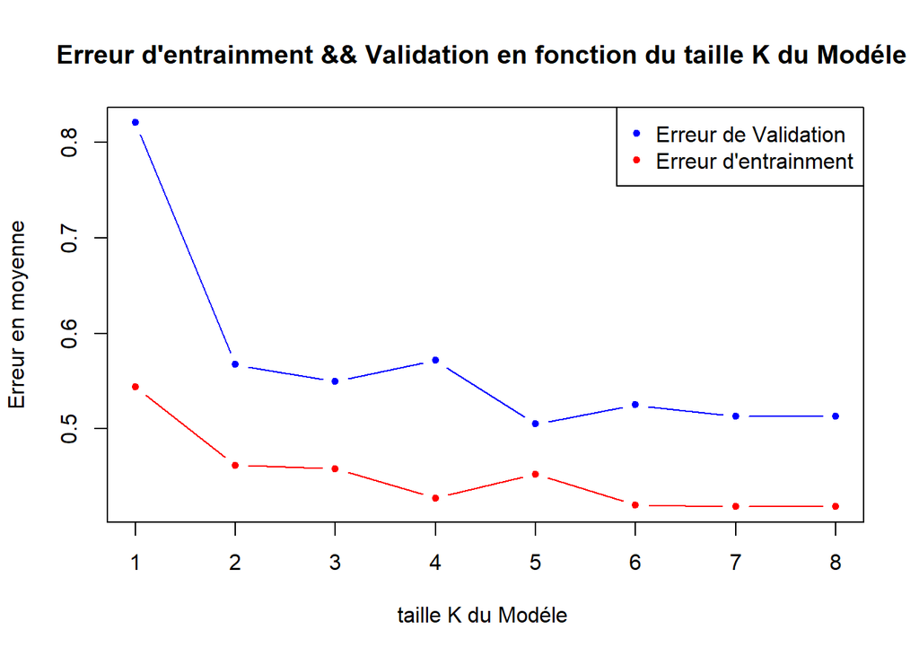

```r
> # plot
> err.train <- sapply(1:8 , function(i) err.train.val[[i]][1])
>
>
> err.validation <- sapply(1:8 , function(i) err.train.val[[i]][2])
>
>
> plot(1:8 , err.validation , col= "blue" , pch=20 ,
+      main = "Erreur d'entrainment && Validation en fonction du taille K du Modéle " ,
+      xlab = "taille K du Modéle " , ylab = "Erreur en moyenne" ,
+      type = "b" ,
+      ylim = c(min(err.train , err.validation) , max(err.train , err.validation)))
>
> points(1:8 , err.train , col="red" , pch=20 ,
+      main = "Erreur d'entrainment en fonction du taille K du Modéle " ,
+      xlab = "taille K du Modéle " , ylab = "Erreur d'entrainment " ,
+      type = "b")
>
>
> legend("topright" , legend = c("Erreur de Validation" , "Erreur d'entrainment") ,
+        col = c("blue" , "red") , pch = 20)
```

### le choix de Modéle :

```r
> summary(lm(lcavol ~ . , data = prostate.data[ , index(7)]))
```

```
Call:
lm(formula = lcavol ~ ., data = prostate.data[, index(7)])

Residuals:
     Min       1Q   Median       3Q      Max
-1.92186 -0.48695 -0.02231  0.55033  1.79957

Coefficients:
             Estimate Std. Error t value Pr(>|t|)
(Intercept) -1.434884   0.690938  -2.077   0.0408 *
age          0.024636   0.010835   2.274   0.0254 *
lbph        -0.105215   0.054671  -1.925   0.0576 .
svi1        -0.220032   0.254775  -0.864   0.3902
lcp          0.402601   0.084533   4.763 7.57e-06 ***
gleason7     0.313300   0.211868   1.479   0.1428
gleason8    -0.709297   0.754080  -0.941   0.3495
gleason9     0.793144   0.481431   1.647   0.1031
pgg45       -0.009438   0.004512  -2.092   0.0394 *
lpsa         0.547767   0.082965   6.602 3.07e-09 ***
---
Signif. codes:  0 '***' 0.001 '**' 0.01 '*' 0.05 '.' 0.1 ' ' 1

Residual standard error: 0.6933 on 87 degrees of freedom
Multiple R-squared:  0.6864,    Adjusted R-squared:  0.654
F-statistic: 21.16 on 9 and 87 DF,  p-value: < 2.2e-16
```

## Question 23

La principale limitation de la validation croisée (split-validation) est qu’elle réduit la quantité de données disponibles pour entraîner le modèle. Lorsque vous divisez les données en ensembles d’entraînement et de validation, vous disposez de moins de points de données pour l’entraînement, ce qui peut conduire à des modèles moins précis, surtout si le jeu de données est petit. Cela peut aboutir à des modèles qui ne généralisent pas bien sur de nouvelles données non vues.

pour résoudre ce probleme :

on peut envisager d’utiliser des techniques comme la validation croisée k-fold. Avec la validation croisée k-fold, le jeu de données est divisé en k sous-ensembles. Le modèle est ensuite entraîné k fois, chaque fois en utilisant k-1 sous-ensembles comme données d’entraînement et le sous-ensemble restant comme données de validation. Les performances du modèle sont ensuite moyennées sur les k essais pour obtenir une estimation plus robuste de la performance du modèle

## Question 24